# 淘宝用户行为数据分析

## **数据读取**

```python
from heapq import merge

import pandas as pd
from pandas.core.dtypes.common import is_datetime64_ns_dtype
from pyparsing import col
```

```python
#原数据太多，防止运行内存不够，只取前2000万条
dtypes_dict = {
    'user_id': 'int32',
    'item_id': 'int32',
    'category_id': 'int32',
    'behavior_type': 'category'
}

taobao = pd.read_csv('UserBehavior.csv', names=['user_id','item_id','item_category','behavior_type','timestamp'], nrows=20000000 ,dtype=dtypes_dict)
```

```python
taobao.info()
```

```
<class 'pandas.DataFrame'>
RangeIndex: 20000000 entries, 0 to 19999999
Data columns (total 5 columns):
 #   Column         Dtype
---  ------         -----
 0   user_id        int32
 1   item_id        int32
 2   item_category  int64
 3   behavior_type  category
 4   timestamp      int64
dtypes: category(1), int32(2), int64(2)
memory usage: 476.8 MB
```

```python
taobao.shape
```

```
(20000000, 5)
```

## **一、数据清洗**

导入数据

查看数据结构

缺失值检查——补缺/去除缺失值

重复值检查——去重

异常值检查

数据类型转换—— data transformation

创建新字段

```python
#查找缺失值
taobao.isnull().sum()
```

```
user_id          0
item_id          0
item_category    0
behavior_type    0
timestamp        0
dtype: int64
```

```python
#检查重复值
taobao.duplicated().sum()
```

```
8
```

```python
#去重
taobao.drop_duplicates(keep='first', inplace=True)
```

```python
taobao.duplicated().sum()
```

```
0
```

```python
#转换时间
taobao['time'] = pd.to_datetime(taobao['timestamp'], unit='s', utc=True).dt.tz_convert('Asia/Shanghai').dt.tz_localize(None)
```

```python
taobao['date'] = taobao['time'].dt.date
taobao['hour'] = taobao['time'].dt.hour
taobao['weekday'] = taobao['time'].dt.day_name()
taobao
```

|  | user_id | item_id | item_category | behavior_type | timestamp | time | date | hour | weekday |
| --- | --- | --- | --- | --- | --- | --- | --- | --- | --- |
| 0 | 1 | 2268318 | 2520377 | pv | 1511544070 | 2017-11-25 01:21:10 | 2017-11-25 | 1 | Saturday |
| 1 | 1 | 2333346 | 2520771 | pv | 1511561733 | 2017-11-25 06:15:33 | 2017-11-25 | 6 | Saturday |
| 2 | 1 | 2576651 | 149192 | pv | 1511572885 | 2017-11-25 09:21:25 | 2017-11-25 | 9 | Saturday |
| 3 | 1 | 3830808 | 4181361 | pv | 1511593493 | 2017-11-25 15:04:53 | 2017-11-25 | 15 | Saturday |
| 4 | 1 | 4365585 | 2520377 | pv | 1511596146 | 2017-11-25 15:49:06 | 2017-11-25 | 15 | Saturday |
| ... | ... | ... | ... | ... | ... | ... | ... | ... | ... |
| 19999995 | 1002513 | 3285794 | 1045172 | pv | 1511883082 | 2017-11-28 23:31:22 | 2017-11-28 | 23 | Tuesday |
| 19999996 | 1002513 | 638230 | 1045172 | pv | 1511883103 | 2017-11-28 23:31:43 | 2017-11-28 | 23 | Tuesday |
| 19999997 | 1002513 | 1286197 | 1045172 | pv | 1511883156 | 2017-11-28 23:32:36 | 2017-11-28 | 23 | Tuesday |
| 19999998 | 1002513 | 2009534 | 1045172 | pv | 1511883279 | 2017-11-28 23:34:39 | 2017-11-28 | 23 | Tuesday |
| 19999999 | 1002513 | 1286197 | 1045172 | pv | 1511883329 | 2017-11-28 23:35:29 | 2017-11-28 | 23 | Tuesday |

19999992 rows × 9 columns

```python
dt_range = taobao['time'].agg(['min', 'max'])
dt_range
```

```
min   1905-07-13 21:54:07
max   2037-04-09 13:22:35
Name: time, dtype: datetime64[s]
```

```python
import datetime
start_day = datetime.date(2017,11,25)
end_day = datetime.date(2017,12,3)

taobao = taobao[(taobao['date'] >= start_day) & (taobao['date'] <= end_day)]

taobao.shape
```

```
(19989198, 9)
```

```python
print(f'数据集跨度时间:{(end_day-start_day).days+1}天')
```

```
数据集跨度时间:9天
```

## **二、探索性数据分析**

数据整体结构：用户数、商品数、行为数分布情况

行为特征分析：pv/cart/fav/buy 占比、趋势

时间规律分析：按天、小时的活跃度

用户维度探索：活跃用户数、行为次数分布

商品维度探索：Top 热门商品/类别

### **数据分布情况**

```python
total_user = taobao['user_id'].nunique()
print(f'总用户数:{total_user}')
total_items = taobao['item_id'].nunique()
print(f'总商品数:{total_items}')
total_category = taobao['item_category'].nunique()
print(f'总类别数:{total_category}')
```

```
总用户数:198001
总商品数:2208950
总类别数:8562
```

### **行为分析**

```python
#每种行为在总行为中的占比
behaviors = taobao.groupby('behavior_type')['behavior_type'].count().reset_index(name='counts')
behaviors['fraction'] = round(behaviors['counts'] / taobao['behavior_type'].count(), 3)
behaviors
```

|  | behavior_type | counts | fraction |
| --- | --- | --- | --- |
| 0 | buy | 404625 | 0.020 |
| 1 | cart | 1107532 | 0.055 |
| 2 | fav | 575114 | 0.029 |
| 3 | pv | 17901927 | 0.896 |

#### 行为分布条形图

```python
import matplotlib.pyplot as plt
import matplotlib.ticker as ticker
```

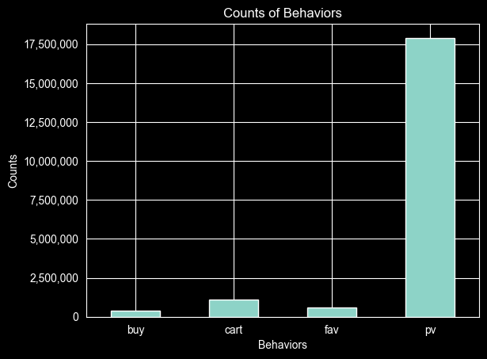

```python
fig,ax = plt.subplots()
behaviors.plot.bar(x='behavior_type', y='counts', ax=ax, rot=0, legend=False)
ax.set_title('Counts of Behaviors')
ax.set_xlabel('Behaviors')
ax.set_ylabel('Counts');
ax.yaxis.set_major_formatter(ticker.StrMethodFormatter('{x:,.0f}'))
```

### **用户行为分析**

#### 访问量与成交量分析：

```python
#访问量分析
taobao_pv = taobao[taobao['behavior_type']=='pv'][['behavior_type', 'date']]
taobao_pv_date = taobao_pv.groupby('date')['behavior_type'].count().reset_index(name='pvs')

#成交量分析
taobao_buy = taobao[taobao['behavior_type']=='buy'][['behavior_type', 'date']]
taobao_buy_date = taobao_buy.groupby('date')['behavior_type'].count().reset_index(name='buys')

#总表
taobao_pv_buy = pd.merge(taobao_pv_date, taobao_buy_date, how='inner', on='date')
taobao_pv_buy
```

|  | date | pvs | buys |
| --- | --- | --- | --- |
| 0 | 2017-11-25 | 1859521 | 39626 |
| 1 | 2017-11-26 | 1904478 | 41291 |
| 2 | 2017-11-27 | 1801051 | 45190 |
| 3 | 2017-11-28 | 1768351 | 42622 |
| 4 | 2017-11-29 | 1832761 | 44389 |
| 5 | 2017-11-30 | 1869388 | 44597 |
| 6 | 2017-12-01 | 1939638 | 42509 |
| 7 | 2017-12-02 | 2470981 | 52291 |
| 8 | 2017-12-03 | 2455758 | 52110 |

[output not shown]

[figure not shown]

```python
#绘图
fig,(ax1,ax2) = plt.subplots(1, 2, figsize=(18,5), dpi=70)
fig.suptitle('总访问量与总成交量趋势对比', fontsize=14)

ax1.plot(taobao_pv_date['date'], taobao_pv_date['pvs'],label='pvs', color='green', linewidth=2)
ax1.set_title('总访问量变化折线图')
ax1.set_xlabel('Date')
ax1.set_ylabel('PV Count')
ax1.grid(False)
ax1.yaxis.set_major_formatter(ticker.StrMethodFormatter('{x:,.0f}'))

ax2.plot(taobao_buy_date['date'], taobao_buy_date['buys'], label='buys',color='blue', linewidth=2)
ax2.set_title('总成交量变化折线图')
ax2.set_xlabel('Date')
ax2.set_ylabel('Order Count')
ax2.grid(False)
ax2.yaxis.set_major_formatter(ticker.StrMethodFormatter('{x:,.0f}'))

fig.autofmt_xdate(rotation=45)
plt.show()
```

#### 每日的用户活跃用户数（DAU）：

```python
#每天的活跃用户数
daily_user = taobao.groupby('date')['user_id'].nunique().reset_index(name='active')
daily_user['date'] = pd.to_datetime(daily_user['date'], format='%Y-%m-%d')
daily_user
```

|  | date | active |
| --- | --- | --- |
| 0 | 2017-11-25 | 141436 |
| 1 | 2017-11-26 | 143267 |
| 2 | 2017-11-27 | 142100 |
| 3 | 2017-11-28 | 142232 |
| 4 | 2017-11-29 | 144101 |
| 5 | 2017-11-30 | 146372 |
| 6 | 2017-12-01 | 148206 |
| 7 | 2017-12-02 | 194450 |
| 8 | 2017-12-03 | 193780 |

[output not shown]

[output cut: 20 more lines]

[figure not shown]

```python
fig,ax=plt.subplots()
daily_user.plot(x='date', y='active', ax=ax, label='active')
ax.set_title('每日活跃用户数（DAU）')
ax.set_xlabel('日期')
ax.set_ylabel('活跃用户数')
ax.grid(False)
plt.show()
```

```python
daily_user['weekday'] = daily_user['date'].dt.day_name()
daily_user
```

|  | date | active | weekday |
| --- | --- | --- | --- |
| 0 | 2017-11-25 | 141436 | Saturday |
| 1 | 2017-11-26 | 143267 | Sunday |
| 2 | 2017-11-27 | 142100 | Monday |
| 3 | 2017-11-28 | 142232 | Tuesday |
| 4 | 2017-11-29 | 144101 | Wednesday |
| 5 | 2017-11-30 | 146372 | Thursday |
| 6 | 2017-12-01 | 148206 | Friday |
| 7 | 2017-12-02 | 194450 | Saturday |
| 8 | 2017-12-03 | 193780 | Sunday |

```python
mean_weekday = daily_user[(daily_user['date'] >= '2017-11-27')&(daily_user['date'] <= '2017-12-01')]['active'].mean()
mean_weekend = daily_user[(daily_user['date'] == '2017-12-02')|(daily_user['date'] == '2017-12-03')]['active'].mean()
increase_rate = round(100*(mean_weekend/mean_weekday-1), 2)
print(f'休息日DAU较工作日增长了{increase_rate}%')
```

```
休息日DAU较工作日增长了34.24%
```

本周六日对比上周六日活跃用户增长率

```python
last_weekend = daily_user[(daily_user['date'] == '2017-11-25')|(daily_user['date'] == '2017-11-26')]['active'].sum()
this_weekend = daily_user[(daily_user['date'] == '2017-12-02')|(daily_user['date'] == '2017-12-03')]['active'].sum()
weekend_ratio_increase = 100*(this_weekend/last_weekend-1)
print(f'休息日活跃用户数增长了{weekend_ratio_increase:.2f}%')
```

```
休息日活跃用户数增长了36.36%
```

进一步地，计算每天每小时的活跃用户数：得到了热力图，其中横轴表示日期，纵轴表示一天的时间分布，每个单元格表示该时段的活跃用户数，颜色越深则活跃用户数越多。

```python
import seaborn as sns
```

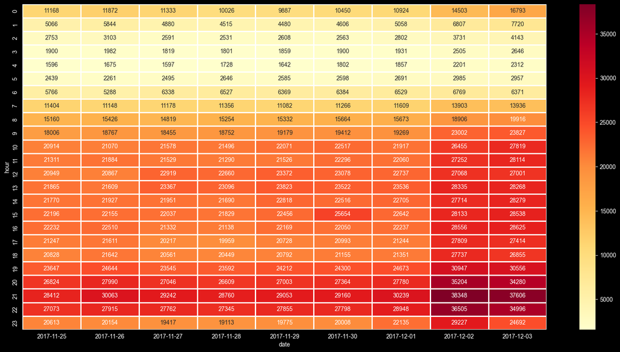

```python
active_hour = taobao.pivot_table(index='hour', columns='date', values='user_id', aggfunc='nunique', fill_value=0)
plt.figure(figsize=(20,10))
sns.heatmap(active_hour, cmap='YlOrRd', annot=True, fmt='d', linewidths=1)
```

#### **每小时平均活跃用户数：**

首先根据日期和时间进行分组，对每日每个时间段的活跃用户数计算统计。 再根据时间段进行分组，对这9天的不同日期的同一时间的活跃用户数计算平均值。

```python
date_hourly_actions = taobao.groupby(['date', 'hour'])['user_id'].nunique().reset_index(name='count')
date_hourly_actions
```

|  | date | hour | count |
| --- | --- | --- | --- |
| 0 | 2017-11-25 | 0 | 11168 |
| 1 | 2017-11-25 | 1 | 5066 |
| 2 | 2017-11-25 | 2 | 2753 |
| 3 | 2017-11-25 | 3 | 1900 |
| 4 | 2017-11-25 | 4 | 1596 |
| ... | ... | ... | ... |
| 211 | 2017-12-03 | 19 | 30556 |
| 212 | 2017-12-03 | 20 | 34280 |
| 213 | 2017-12-03 | 21 | 37606 |
| 214 | 2017-12-03 | 22 | 34996 |
| 215 | 2017-12-03 | 23 | 24692 |

216 rows × 3 columns

```python
hourly_actions = date_hourly_actions.groupby('hour')['count'].mean()
hourly_actions
```

```
hour
0     11884.000000
1      5441.777778
2      2980.555556
3      2038.111111
4      1823.333333
5      2628.555556
6      6260.111111
7     11875.777778
8     16238.888889
9     19852.111111
10    22870.777778
11    23029.111111
12    23405.666667
13    24157.888889
14    23485.555556
15    23960.000000
16    23427.666667
17    22358.000000
18    22374.444444
19    25568.444444
20    28900.000000
21    31209.222222
22    29577.444444
23    21681.555556
Name: count, dtype: float64
```

统计每个时间段不同行为的用户数

```python
actives = taobao.groupby(['date', 'hour', 'behavior_type'])['user_id'].nunique().reset_index(name='activeusers')
actives
```

|  | date | hour | behavior_type | activeusers |
| --- | --- | --- | --- | --- |
| 0 | 2017-11-25 | 0 | buy | 776 |
| 1 | 2017-11-25 | 0 | cart | 2138 |
| 2 | 2017-11-25 | 0 | fav | 1192 |
| 3 | 2017-11-25 | 0 | pv | 10651 |
| 4 | 2017-11-25 | 1 | buy | 332 |
| ... | ... | ... | ... | ... |
| 859 | 2017-12-03 | 22 | pv | 33134 |
| 860 | 2017-12-03 | 23 | buy | 1901 |
| 861 | 2017-12-03 | 23 | cart | 6003 |
| 862 | 2017-12-03 | 23 | fav | 2781 |
| 863 | 2017-12-03 | 23 | pv | 23388 |

864 rows × 4 columns

### **商品数据探索**

目标：找到Top热门商品/品类——取Top10

对热门商品的定义有许多种，可以是用点击量进行排名（流量热度），也可以是销量进行排名（销量热度），这里我们不仅利用点击量和销量对商品进行排名，还会综合商品的不同指标计算综合热度。

综合热度考虑了商品的点击量（pv），收藏量（fav），加购量（cart）和销量（buy），计算过程中为不同的用户行为设置了权重，权重的设置利用经验法，点击权重为1，收藏权重为3，加购权重为5，销量权重为10。权重的分值的设定可以利用其他的方法。

商品热度Top10计算

```python
#产品热度
heat_score = {'pv':1, 'fav':3, 'cart':5, 'buy':10}
#流量热度
pv_top = taobao[taobao['behavior_type']=='pv']['item_id'].value_counts().reset_index()
#销量热度
sale_top = taobao[taobao['behavior_type']=='buy']['item_id'].value_counts().reset_index()
#综合热度
taobao['score_heat'] = taobao['behavior_type'].map(heat_score).astype(float)
heat_top_item = taobao.groupby('item_id')['score_heat'].sum().reset_index().sort_values(by='score_heat', ascending=False).reset_index(drop=True)
#综合表
items_top10 = pd.concat([pv_top.head(10), sale_top.head(10), heat_top_item.head(10)], axis=1, keys=['pv_top10', 'sale_top10', 'heat_top10'])
items_top10
```

|  | pv_top10 item_id | pv_top10 count | sale_top10 item_id | sale_top10 count | heat_top10 item_id | heat_top10 score_heat |
| --- | --- | --- | --- | --- | --- | --- |
| 0 | 812879 | 6014 | 3122135 | 292 | 812879 | 8241.0 |
| 1 | 3845720 | 5098 | 3031354 | 161 | 3031354 | 7127.0 |
| 2 | 138964 | 4194 | 2560262 | 137 | 3845720 | 6581.0 |
| 3 | 2331370 | 3916 | 2964774 | 135 | 2331370 | 6265.0 |
| 4 | 2032668 | 3798 | 1910706 | 133 | 138964 | 5892.0 |
| 5 | 59883 | 3553 | 3964583 | 133 | 1535294 | 5809.0 |
| 6 | 1535294 | 3537 | 1415828 | 119 | 2818406 | 5088.0 |
| 7 | 3031354 | 3475 | 1116492 | 115 | 2560262 | 5067.0 |
| 8 | 3371523 | 3460 | 1034594 | 107 | 4443059 | 5039.0 |
| 9 | 4211339 | 3392 | 740947 | 106 | 2453685 | 4790.0 |

```python
print(items_top10.to_markdown(index=False, floatfmt='.0f'))
```

```
|   ('pv_top10', 'item_id') |   ('pv_top10', 'count') |   ('sale_top10', 'item_id') |   ('sale_top10', 'count') |   ('heat_top10', 'item_id') |   ('heat_top10', 'score_heat') |
|--------------------------:|------------------------:|----------------------------:|--------------------------:|----------------------------:|-------------------------------:|
|                    812879 |                    6014 |                     3122135 |                       292 |                      812879 |                           8241 |
|                   3845720 |                    5098 |                     3031354 |                       161 |                     3031354 |                           7127 |
|                    138964 |                    4194 |                     2560262 |                       137 |                     3845720 |                           6581 |
|                   2331370 |                    3916 |                     2964774 |                       135 |                     2331370 |                           6265 |
|                   2032668 |                    3798 |                     1910706 |                       133 |                      138964 |                           5892 |
|                     59883 |                    3553 |                     3964583 |                       133 |                     1535294 |                           5809 |
|                   1535294 |                    3537 |                     1415828 |                       119 |                     2818406 |                           5088 |
|                   3031354 |                    3475 |                     1116492 |                       115 |                     2560262 |                           5067 |
|                   3371523 |                    3460 |                     1034594 |                       107 |                     4443059 |                           5039 |
|                   4211339 |                    3392 |                      740947 |                       106 |                     2453685 |                           4790 |
```

品类热度Top10计算

```python
#流量热度
pv_cat_top10 = taobao[taobao['behavior_type'] == 'pv']['item_category'].value_counts().reset_index()
#销量热度
sale_cat_top10 = taobao[taobao['behavior_type'] == 'buy']['item_category'].value_counts().reset_index()
#综合热度
heat_top10_cat = taobao.groupby('item_category')['score_heat'].sum().reset_index().sort_values(by='score_heat', ascending=False).reset_index(drop=True)
#综合表
cat_top10 = pd.concat([pv_cat_top10.head(10), sale_cat_top10.head(10), heat_top10_cat.head(10)], axis=1, keys=['cat_pv_top10', 'cat_sale_top10', 'cat_heat_top10'])
cat_top10
```

|  | cat_pv_top10 item_category | cat_pv_top10 count | cat_sale_top10 item_category | cat_sale_top10 count | cat_heat_top10 item_category | cat_heat_top10 score_heat |
| --- | --- | --- | --- | --- | --- | --- |
| 0 | 4756105 | 901040 | 1464116 | 7030 | 4756105 | 1256896.0 |
| 1 | 4145813 | 634522 | 2735466 | 6774 | 4145813 | 939674.0 |
| 2 | 2355072 | 623979 | 4145813 | 6475 | 2355072 | 820424.0 |
| 3 | 3607361 | 587034 | 2885642 | 6329 | 982926 | 813789.0 |
| 4 | 982926 | 558090 | 4756105 | 5536 | 3607361 | 762573.0 |
| 5 | 2520377 | 401186 | 4801426 | 5281 | 4801426 | 586987.0 |
| 6 | 4801426 | 371631 | 982926 | 4989 | 2520377 | 547022.0 |
| 7 | 1320293 | 355507 | 2640118 | 3727 | 1320293 | 514543.0 |
| 8 | 2465336 | 303424 | 4159072 | 3561 | 2465336 | 449955.0 |
| 9 | 3002561 | 283270 | 1320293 | 3405 | 3002561 | 429718.0 |

```python
print(cat_top10.to_markdown(index=False, floatfmt='.0f'))
```

```
|   ('cat_pv_top10', 'item_category') |   ('cat_pv_top10', 'count') |   ('cat_sale_top10', 'item_category') |   ('cat_sale_top10', 'count') |   ('cat_heat_top10', 'item_category') |   ('cat_heat_top10', 'score_heat') |
|------------------------------------:|----------------------------:|--------------------------------------:|------------------------------:|--------------------------------------:|-----------------------------------:|
|                             4756105 |                      901040 |                               1464116 |                          7030 |                               4756105 |                            1256896 |
|                             4145813 |                      634522 |                               2735466 |                          6774 |                               4145813 |                             939674 |
|                             2355072 |                      623979 |                               4145813 |                          6475 |                               2355072 |                             820424 |
|                             3607361 |                      587034 |                               2885642 |                          6329 |                                982926 |                             813789 |
|                              982926 |                      558090 |                               4756105 |                          5536 |                               3607361 |                             762573 |
|                             2520377 |                      401186 |                               4801426 |                          5281 |                               4801426 |                             586987 |
|                             4801426 |                      371631 |                                982926 |                          4989 |                               2520377 |                             547022 |
|                             1320293 |                      355507 |                               2640118 |                          3727 |                               1320293 |                             514543 |
|                             2465336 |                      303424 |                               4159072 |                          3561 |                               2465336 |                             449955 |
|                             3002561 |                      283270 |                               1320293 |                          3405 |                               3002561 |                             429718 |
```

## **三、用户流量分析**

### **用户获取分析**

计算每日点击量（pv），浏览人数（uv），和每位访客的平均页面浏览量（pv/uv）

PV/UV（人均浏览量）：衡量用户粘性的核心指标。

- PV/UV较高：比率通常意味着用户在网站上停留的时间更长、参与度更高，并且对内容或服务更感兴趣。
- PV/UV较低：比率可能表明大多数用户只访问了一个页面就离开了，导致“跳出率”较高。

```python
pv_user = taobao[taobao['behavior_type'] == 'pv'].groupby('date').agg(pv = ('behavior_type', 'count'), uv = ('user_id', 'nunique')).reset_index()
pv_user['pv/uv'] = round(pv_user['pv']/pv_user['uv'], 2)
pv_user
```

|  | date | pv | uv | pv/uv |
| --- | --- | --- | --- | --- |
| 0 | 2017-11-25 | 1859521 | 137512 | 13.52 |
| 1 | 2017-11-26 | 1904478 | 139340 | 13.67 |
| 2 | 2017-11-27 | 1801051 | 137902 | 13.06 |
| 3 | 2017-11-28 | 1768351 | 137948 | 12.82 |
| 4 | 2017-11-29 | 1832761 | 139822 | 13.11 |
| 5 | 2017-11-30 | 1869388 | 142029 | 13.16 |
| 6 | 2017-12-01 | 1939638 | 143843 | 13.48 |
| 7 | 2017-12-02 | 2470981 | 188292 | 13.12 |
| 8 | 2017-12-03 | 2455758 | 187693 | 13.08 |

### **用户留存分析**

留存率计算方法：第n日留存率=第n日仍登录的用户数/首日用户登录数

```python
user_login_date = taobao[['user_id', 'date']].drop_duplicates()

first_login = user_login_date.groupby('user_id')['date'].min().reset_index(name='first_login')

user_login_date['date'] = pd.to_datetime(user_login_date['date'])
first_login['first_login'] = pd.to_datetime(first_login['first_login'])
user_login_date
```

|  | user_id | date |
| --- | --- | --- |
| 0 | 1 | 2017-11-25 |
| 6 | 1 | 2017-11-26 |
| 7 | 1 | 2017-11-27 |
| 15 | 1 | 2017-11-28 |
| 22 | 1 | 2017-11-29 |
| ... | ... | ... |
| 19999965 | 1002510 | 2017-12-02 |
| 19999968 | 1002510 | 2017-12-03 |
| 19999976 | 1002513 | 2017-11-26 |
| 19999983 | 1002513 | 2017-11-27 |
| 19999991 | 1002513 | 2017-11-28 |

1395944 rows × 2 columns

```python
user_active = pd.merge(user_login_date, first_login, how='left', on='user_id')
user_active['datediff'] = (user_active['date'] - user_active['first_login']).dt.days
user_active
```

|  | user_id | date | first_login | datediff |
| --- | --- | --- | --- | --- |
| 0 | 1 | 2017-11-25 | 2017-11-25 | 0 |
| 1 | 1 | 2017-11-26 | 2017-11-25 | 1 |
| 2 | 1 | 2017-11-27 | 2017-11-25 | 2 |
| 3 | 1 | 2017-11-28 | 2017-11-25 | 3 |
| 4 | 1 | 2017-11-29 | 2017-11-25 | 4 |
| ... | ... | ... | ... | ... |
| 1395939 | 1002510 | 2017-12-02 | 2017-11-26 | 6 |
| 1395940 | 1002510 | 2017-12-03 | 2017-11-26 | 7 |
| 1395941 | 1002513 | 2017-11-26 | 2017-11-26 | 0 |
| 1395942 | 1002513 | 2017-11-27 | 2017-11-26 | 1 |
| 1395943 | 1002513 | 2017-11-28 | 2017-11-26 | 2 |

1395944 rows × 4 columns

```python
def count_rate(x, d):
    ret = x[x['datediff'] == d]['user_id'].nunique()
    user = x['user_id'].nunique()
    return round(ret/user*100, 2)
```

```python
ret1 = user_active.groupby('first_login').apply(lambda x:count_rate(x, 1)).reset_index(name='ret1')
ret3 = user_active.groupby('first_login').apply(lambda x:count_rate(x, 3)).reset_index(name='ret3')

retention = pd.merge(ret1, ret3, on='first_login', how='inner')
retention
```

|  | first_login | ret1 | ret3 |
| --- | --- | --- | --- |
| 0 | 2017-11-25 | 78.77 | 75.97 |
| 1 | 2017-11-26 | 64.87 | 65.91 |
| 2 | 2017-11-27 | 61.21 | 65.02 |
| 3 | 2017-11-28 | 61.76 | 66.99 |
| 4 | 2017-11-29 | 69.81 | 96.45 |
| 5 | 2017-11-30 | 94.44 | 95.24 |
| 6 | 2017-12-01 | 92.86 | 0.00 |
| 7 | 2017-12-02 | 75.00 | 0.00 |

```python
retention['ret1'].mean()
```

```
74.84
```

```python
cohort_data = user_active.groupby(['first_login', 'datediff'])['user_id'].nunique().reset_index(name='counts')
cohort_data
```

|  | first_login | datediff | counts |
| --- | --- | --- | --- |
| 0 | 2017-11-25 | 0 | 141436 |
| 1 | 2017-11-25 | 1 | 111409 |
| 2 | 2017-11-25 | 2 | 108619 |
| 3 | 2017-11-25 | 3 | 107447 |
| 4 | 2017-11-25 | 4 | 107577 |
| 5 | 2017-11-25 | 5 | 108369 |
| 6 | 2017-11-25 | 6 | 109286 |
| 7 | 2017-11-25 | 7 | 139333 |
| 8 | 2017-11-25 | 8 | 138951 |
| 9 | 2017-11-26 | 0 | 31858 |
| 10 | 2017-11-26 | 1 | 20667 |
| 11 | 2017-11-26 | 2 | 20591 |
| 12 | 2017-11-26 | 3 | 20999 |
| 13 | 2017-11-26 | 4 | 21271 |
| 14 | 2017-11-26 | 5 | 21797 |
| 15 | 2017-11-26 | 6 | 31162 |
| 16 | 2017-11-26 | 7 | 30997 |
| 17 | 2017-11-27 | 0 | 12814 |
| 18 | 2017-11-27 | 1 | 7844 |
| 19 | 2017-11-27 | 2 | 7999 |
| 20 | 2017-11-27 | 3 | 8332 |
| 21 | 2017-11-27 | 4 | 8442 |
| 22 | 2017-11-27 | 5 | 12476 |
| 23 | 2017-11-27 | 6 | 12409 |
| 24 | 2017-11-28 | 0 | 6350 |
| 25 | 2017-11-28 | 1 | 3922 |
| 26 | 2017-11-28 | 2 | 3995 |
| 27 | 2017-11-28 | 3 | 4254 |
| 28 | 2017-11-28 | 4 | 6145 |
| 29 | 2017-11-28 | 5 | 6115 |
| 30 | 2017-11-29 | 0 | 3604 |
| 31 | 2017-11-29 | 1 | 2516 |
| 32 | 2017-11-29 | 2 | 2601 |
| 33 | 2017-11-29 | 3 | 3476 |
| 34 | 2017-11-29 | 4 | 3462 |
| 35 | 2017-11-30 | 0 | 1889 |
| 36 | 2017-11-30 | 1 | 1784 |
| 37 | 2017-11-30 | 2 | 1811 |
| 38 | 2017-11-30 | 3 | 1799 |
| 39 | 2017-12-01 | 0 | 42 |
| 40 | 2017-12-01 | 1 | 39 |
| 41 | 2017-12-01 | 2 | 41 |
| 42 | 2017-12-02 | 0 | 8 |
| 43 | 2017-12-02 | 1 | 6 |

```python
new_users = cohort_data[cohort_data['datediff']==0][['first_login', 'counts']]
new_users.rename(columns={'counts':'new_user_count'}, inplace=True)
new_users
```

|  | first_login | new_user_count |
| --- | --- | --- |
| 0 | 2017-11-25 | 141436 |
| 9 | 2017-11-26 | 31858 |
| 17 | 2017-11-27 | 12814 |
| 24 | 2017-11-28 | 6350 |
| 30 | 2017-11-29 | 3604 |
| 35 | 2017-11-30 | 1889 |
| 39 | 2017-12-01 | 42 |
| 42 | 2017-12-02 | 8 |

```python
cohort_data = cohort_data.merge(new_users, how='left', on='first_login')
cohort_data['retention_rate'] = round(cohort_data['counts']/cohort_data['new_user_count'], 2)
cohort_data
```

|  | first_login | datediff | counts | new_user_count | retention_rate |
| --- | --- | --- | --- | --- | --- |
| 0 | 2017-11-25 | 0 | 141436 | 141436 | 1.00 |
| 1 | 2017-11-25 | 1 | 111409 | 141436 | 0.79 |
| 2 | 2017-11-25 | 2 | 108619 | 141436 | 0.77 |
| 3 | 2017-11-25 | 3 | 107447 | 141436 | 0.76 |
| 4 | 2017-11-25 | 4 | 107577 | 141436 | 0.76 |
| 5 | 2017-11-25 | 5 | 108369 | 141436 | 0.77 |
| 6 | 2017-11-25 | 6 | 109286 | 141436 | 0.77 |
| 7 | 2017-11-25 | 7 | 139333 | 141436 | 0.99 |
| 8 | 2017-11-25 | 8 | 138951 | 141436 | 0.98 |
| 9 | 2017-11-26 | 0 | 31858 | 31858 | 1.00 |
| 10 | 2017-11-26 | 1 | 20667 | 31858 | 0.65 |
| 11 | 2017-11-26 | 2 | 20591 | 31858 | 0.65 |
| 12 | 2017-11-26 | 3 | 20999 | 31858 | 0.66 |
| 13 | 2017-11-26 | 4 | 21271 | 31858 | 0.67 |
| 14 | 2017-11-26 | 5 | 21797 | 31858 | 0.68 |
| 15 | 2017-11-26 | 6 | 31162 | 31858 | 0.98 |
| 16 | 2017-11-26 | 7 | 30997 | 31858 | 0.97 |
| 17 | 2017-11-27 | 0 | 12814 | 12814 | 1.00 |
| 18 | 2017-11-27 | 1 | 7844 | 12814 | 0.61 |
| 19 | 2017-11-27 | 2 | 7999 | 12814 | 0.62 |
| 20 | 2017-11-27 | 3 | 8332 | 12814 | 0.65 |
| 21 | 2017-11-27 | 4 | 8442 | 12814 | 0.66 |
| 22 | 2017-11-27 | 5 | 12476 | 12814 | 0.97 |
| 23 | 2017-11-27 | 6 | 12409 | 12814 | 0.97 |
| 24 | 2017-11-28 | 0 | 6350 | 6350 | 1.00 |
| 25 | 2017-11-28 | 1 | 3922 | 6350 | 0.62 |
| 26 | 2017-11-28 | 2 | 3995 | 6350 | 0.63 |
| 27 | 2017-11-28 | 3 | 4254 | 6350 | 0.67 |
| 28 | 2017-11-28 | 4 | 6145 | 6350 | 0.97 |
| 29 | 2017-11-28 | 5 | 6115 | 6350 | 0.96 |
| 30 | 2017-11-29 | 0 | 3604 | 3604 | 1.00 |
| 31 | 2017-11-29 | 1 | 2516 | 3604 | 0.70 |
| 32 | 2017-11-29 | 2 | 2601 | 3604 | 0.72 |
| 33 | 2017-11-29 | 3 | 3476 | 3604 | 0.96 |
| 34 | 2017-11-29 | 4 | 3462 | 3604 | 0.96 |
| 35 | 2017-11-30 | 0 | 1889 | 1889 | 1.00 |
| 36 | 2017-11-30 | 1 | 1784 | 1889 | 0.94 |
| 37 | 2017-11-30 | 2 | 1811 | 1889 | 0.96 |
| 38 | 2017-11-30 | 3 | 1799 | 1889 | 0.95 |
| 39 | 2017-12-01 | 0 | 42 | 42 | 1.00 |
| 40 | 2017-12-01 | 1 | 39 | 42 | 0.93 |
| 41 | 2017-12-01 | 2 | 41 | 42 | 0.98 |
| 42 | 2017-12-02 | 0 | 8 | 8 | 1.00 |
| 43 | 2017-12-02 | 1 | 6 | 8 | 0.75 |

```python
#提取出25日的数据
cohort_data[cohort_data['first_login']=='2017-11-25']
```

|  | first_login | datediff | counts | new_user_count | retention_rate |
| --- | --- | --- | --- | --- | --- |
| 0 | 2017-11-25 | 0 | 141436 | 141436 | 1.00 |
| 1 | 2017-11-25 | 1 | 111409 | 141436 | 0.79 |
| 2 | 2017-11-25 | 2 | 108619 | 141436 | 0.77 |
| 3 | 2017-11-25 | 3 | 107447 | 141436 | 0.76 |
| 4 | 2017-11-25 | 4 | 107577 | 141436 | 0.76 |
| 5 | 2017-11-25 | 5 | 108369 | 141436 | 0.77 |
| 6 | 2017-11-25 | 6 | 109286 | 141436 | 0.77 |
| 7 | 2017-11-25 | 7 | 139333 | 141436 | 0.99 |
| 8 | 2017-11-25 | 8 | 138951 | 141436 | 0.98 |

## **四、转化漏斗分析**

目标：分析用户从 浏览 → 收藏/加购 → 购买 的转化情况，找到流失最多的环节。

```python
#浏览的人数
pv_users = taobao[taobao['behavior_type']=='pv'][['user_id']]
pv_users_count = taobao[taobao['behavior_type']=='pv']['user_id'].nunique()
```

```python
#所有 收藏/加购 的人数
fav_cart_user = taobao[taobao['behavior_type'].isin(['fav', 'cart'])][['user_id']]
#浏览后 收藏/加购 的人数
pv_fav_cart_user = fav_cart_user[fav_cart_user['user_id'].isin(pv_users['user_id'])][['user_id']]
pv_fav_cart_user_count = pv_fav_cart_user['user_id'].nunique()
#所有购买的人数
buy_users = taobao[taobao['behavior_type']=='buy'][['user_id']]
#浏览 - 收藏/加购 后购买的人数
pv_fav_cart_buy_user = buy_users[buy_users['user_id'].isin(pv_fav_cart_user['user_id'])][['user_id']]
pv_fav_cart_buy_user_count = pv_fav_cart_buy_user['user_id'].nunique()
#所有浏览后购买的人数
pv_buy_user = buy_users[buy_users['user_id'].isin(pv_users['user_id'])][['user_id']]
pv_buy_user_count = pv_buy_user['user_id'].nunique()
#浏览后直接购买的人数（无收藏/加购）
pv__buy_user = pv_buy_user[~pv_buy_user['user_id'].isin(fav_cart_user['user_id'])][['user_id']]
pv__buy_user_count = pv__buy_user['user_id'].nunique()
```

```python
#-----计算转化率-----
#浏览-收藏/加购 转化率
rate_pv_fav_cart = round(100*pv_fav_cart_user_count/pv_users_count, 2)
#浏览收藏加购-购买 转化率
rate_pv_fav_cart_buy = round(100*pv_fav_cart_buy_user_count/pv_fav_cart_user_count, 2)
#整体转化率  所有浏览后购买的人数/所有浏览的人数
rate_pv_buy = round(100*pv_buy_user['user_id'].nunique()/pv_users_count, 2)
#静默下单率  浏览后直接购买的人数（无收藏/加购）/所有浏览的人数
rate_pv__buy = round(100*pv__buy_user_count/pv_users_count, 2)

print(f'浏览-收藏/加购 转化率:{rate_pv_fav_cart}%')
print(f'浏览收藏加购-购买 转化率:{rate_pv_fav_cart_buy}%')
print(f'整体转化率:{rate_pv_buy}%')
print(f'静默下单率:{rate_pv__buy}%')
```

```
浏览-收藏/加购 转化率:87.02%
浏览收藏加购-购买 转化率:70.2%
整体转化率:68.13%
静默下单率:7.04%
```

**上面的方法较为粗糙，虽然逻辑清晰，但是存在漏洞。**

- 漏洞 A（跨商品乱组CP）：用户浏览了商品A，却加购了商品B。在这个粗暴逻辑里，因为这个用户既在“浏览名单”里，又在“加购名单”里，所以他被算作了成功的转化。但这在业务上是毫无因果关系的假转化！
- 漏洞 B（时间倒流）：用户可能在11月1日加购了商品B（通过列表页快捷加购），然后到了11月5日才点进去浏览了商品B。在这个作者的代码里，也算作了“浏览->加购”的漏斗成功。但时间顺序是反的！

结论：这段代码，只能叫做“大盘用户行为渗透率分析”（有多少人既逛了又买了），根本不能叫严谨的“转化漏斗分析”！

### **下面是另一种方法：**

构造每个用户在每个商品上的完整行为路径，只要用户对商品进行了操作，其行为就标为1。要明确的是，漏斗的分析对象，在此项目中，转化漏斗的分析对象是用户，目的是构造用户的完整行为路径，我的问题是有多少用户从浏览 → 加购 → 购买？

- 漏斗第一层：计算所有浏览过商品的用户数量
- 漏斗第二层：计算浏览后商品后对商品有收藏或加购行为的用户数量
- 漏斗第三层：计算浏览并收藏或加购后，最终购买的用户数量

```python
#提取基础表
user_behavior = taobao[['user_id', 'item_id','behavior_type']]
user_behavior['flag'] = 1
user_behavior
```

|  | user_id | item_id | behavior_type | flag |
| --- | --- | --- | --- | --- |
| 0 | 1 | 2268318 | pv | 1 |
| 1 | 1 | 2333346 | pv | 1 |
| 2 | 1 | 2576651 | pv | 1 |
| 3 | 1 | 3830808 | pv | 1 |
| 4 | 1 | 4365585 | pv | 1 |
| ... | ... | ... | ... | ... |
| 19999995 | 1002513 | 3285794 | pv | 1 |
| 19999996 | 1002513 | 638230 | pv | 1 |
| 19999997 | 1002513 | 1286197 | pv | 1 |
| 19999998 | 1002513 | 2009534 | pv | 1 |
| 19999999 | 1002513 | 1286197 | pv | 1 |

19989198 rows × 4 columns

```python
#数据透视表
users = user_behavior.pivot_table(index=['user_id', 'item_id'], columns='behavior_type', values='flag', aggfunc='max').fillna(0).reset_index()
users[['buy', 'cart', 'fav', 'pv']] = users[['buy', 'cart', 'fav', 'pv']].astype(int)
users = users.rename(columns={col:col+'_cnt' for col in ['pv', 'fav', 'cart', 'buy']})
users
```

| behavior_type | user_id | item_id | buy_cnt | cart_cnt | fav_cnt | pv_cnt |
| --- | --- | --- | --- | --- | --- | --- |
| 0 | 1 | 46259 | 0 | 0 | 0 | 1 |
| 1 | 1 | 79715 | 0 | 0 | 0 | 1 |
| 2 | 1 | 230380 | 0 | 0 | 0 | 1 |
| 3 | 1 | 266784 | 0 | 0 | 0 | 1 |
| 4 | 1 | 271696 | 0 | 0 | 0 | 1 |
| ... | ... | ... | ... | ... | ... | ... |
| 15173444 | 1018011 | 3432631 | 0 | 0 | 0 | 1 |
| 15173445 | 1018011 | 4229934 | 0 | 0 | 0 | 1 |
| 15173446 | 1018011 | 4267263 | 0 | 0 | 0 | 1 |
| 15173447 | 1018011 | 4511938 | 0 | 0 | 0 | 1 |
| 15173448 | 1018011 | 4831939 | 0 | 0 | 0 | 1 |

15173449 rows × 6 columns

```python
#显示用户路径
users['user_behavior_path'] = (users['pv_cnt'].astype(str) + users['cart_cnt'].astype(str) + users['fav_cnt'].astype(str) + users['buy_cnt'].astype(str))
users
```

| behavior_type | user_id | item_id | buy_cnt | cart_cnt | fav_cnt | pv_cnt | user_behavior_path |
| --- | --- | --- | --- | --- | --- | --- | --- |
| 0 | 1 | 46259 | 0 | 0 | 0 | 1 | 1000 |
| 1 | 1 | 79715 | 0 | 0 | 0 | 1 | 1000 |
| 2 | 1 | 230380 | 0 | 0 | 0 | 1 | 1000 |
| 3 | 1 | 266784 | 0 | 0 | 0 | 1 | 1000 |
| 4 | 1 | 271696 | 0 | 0 | 0 | 1 | 1000 |
| ... | ... | ... | ... | ... | ... | ... | ... |
| 15173444 | 1018011 | 3432631 | 0 | 0 | 0 | 1 | 1000 |
| 15173445 | 1018011 | 4229934 | 0 | 0 | 0 | 1 | 1000 |
| 15173446 | 1018011 | 4267263 | 0 | 0 | 0 | 1 | 1000 |
| 15173447 | 1018011 | 4511938 | 0 | 0 | 0 | 1 | 1000 |
| 15173448 | 1018011 | 4831939 | 0 | 0 | 0 | 1 | 1000 |

15173449 rows × 7 columns

```python
users.to_csv('users.csv', index=False)
```

```python
#漏斗第一层：浏览用户的数量
pvs = users[users['pv_cnt']==1]['user_id'].nunique()
print(f'浏览用户的数量:{pvs}')
#漏斗第二层：浏览后收藏或加购物车的用户数量
pv_favcarts = users[(users['pv_cnt']==1)&((users['fav_cnt']==1)|(users['cart_cnt']==1))]['user_id'].nunique()
#pv_favcarts = users[users['user_behavior_path'].isin(['1100', '1110', '1010', '1101', '1111', '1011'])]['user_id'].nunique()
print(f'浏览后收藏或加购物车的用户数量:{pv_favcarts}')
#漏斗第三层：浏览-收藏/加购后购买的用户数量
pv_favcart_buys = users[users['user_behavior_path'].isin(['1101', '1111', '1011'])]['user_id'].nunique()
print(f'浏览-收藏/加购后购买的用户数量:{pv_favcart_buys}')

#浏览-收藏/加购物车 转化率
pv_favcarts_rate = round(100*pv_favcarts/pvs, 2)
print(f'浏览-收藏/加购物车 转化率:{pv_favcarts_rate}%')
#(浏览-收藏/加购物车)-购买 转化率
pv_favcart_buys_rate = round(100*pv_favcart_buys/pv_favcarts, 2)
print(f'(浏览-收藏/加购物车)-购买 转化率:{pv_favcart_buys_rate}%')
```

```
浏览用户的数量:197231
浏览后收藏或加购物车的用户数量:147637
浏览-收藏/加购后购买的用户数量:48399
浏览-收藏/加购物车 转化率:74.85%
(浏览-收藏/加购物车)-购买 转化率:32.78%
```

进一步地，我想进行灵活一点的计算，例如计算所有进行浏览的用户中，最终购买的用户比例，即「浏览→购买」的转化率。

```python
#浏览->购买 的转化率（包含收藏加购物车和未收藏加购物车）
all_buys_from_pv = users[users['user_behavior_path'].isin(['1001', '1101', '1011', '1111'])]['user_id'].nunique()
buys_from_pv_rate = round(100*all_buys_from_pv/pvs, 2)
print(f'浏览->购买的转化率:{buys_from_pv_rate}%')

#收藏/加购->购买 的转化率（包含浏览和未浏览）
favcarts = users[(users['fav_cnt']==1)|(users['cart_cnt']==1)]['user_id'].nunique()
all_buys_from_favcart = users[((users['fav_cnt']==1)|(users['cart_cnt']==1))&(users['buy_cnt']==1)]['user_id'].nunique()
buys_from_favcart_rate = round(100*all_buys_from_favcart/favcarts, 2)
print(f'收藏/加购->购买 的转化率:{buys_from_favcart_rate}%')

#浏览后直接购买的比例
buys_after_pv = users[users['user_behavior_path']=='1001']['user_id'].nunique()
buys_after_pv_rate = round(100*buys_after_pv/pvs, 2)
print(f'浏览后直接购买的比例:{buys_after_pv_rate}%')

#无浏览直接收藏/加购->购买 的比例
buys_without_pv = users[users['user_behavior_path'].isin(['0101', '0011'])]['user_id'].nunique()
favcarts_without_pv = users[(users['pv_cnt']==0)&((users['fav_cnt']==1)|(users['cart_cnt']==1))]['user_id'].nunique()
buys_without_pv_rate = round(100*buys_without_pv/favcarts_without_pv, 2)
print(f'无浏览直接收藏/加购->购买 的比例:{buys_without_pv_rate}%')

#未浏览/收藏/加购物车，直接购买的用户比例
direct_buys = users[users['user_behavior_path']=='0001']['user_id'].nunique()
all_buys = users[users['buy_cnt']==1]['user_id'].nunique()
direct_buys_rate = round(100*direct_buys/all_buys, 2)
print(f'未浏览/收藏/加购物车，直接购买的用户比例:{direct_buys_rate}%')
```

```
浏览->购买的转化率:56.58%
收藏/加购->购买 的转化率:33.85%
浏览后直接购买的比例:46.86%
无浏览直接收藏/加购->购买 的比例:11.11%
未浏览/收藏/加购物车，直接购买的用户比例:46.16%
```

```python
df = [
    {'漏斗路径':'浏览➡收藏/加购物车',
     '分母':'浏览过商品的用户数',
     '分子':'浏览后收藏/加购物车的用户数',
     '转化率':f'{pv_favcarts_rate}%'},
    {'漏斗路径':'浏览➡收藏/加购物车➡购买',
     '分母':'浏览后收藏/加购物车的用户数',
     '分子':'浏览后收藏/加购物车并且购买的用户数',
     '转化率':f'{pv_favcart_buys_rate}%'},
    {'漏斗路径':'浏览➡购买',
     '分母':'浏览过商品的用户数',
     '分子':'浏览过商品并且最终购买的用户数',
     '转化率':f'{buys_from_pv_rate}%'},
    {'漏斗路径':'收藏/加购物车➡购买',
     '分母':'收藏/加购物车的用户数',
     '分子':'收藏/加购物车后购买的用户数',
     '转化率':f'{buys_from_favcart_rate}%'},
    {'漏斗路径':'浏览➡购买（直购）',
     '分母':'浏览过商品的用户数',
     '分子':'浏览后直接购买的用户数',
     '转化率':f'{buys_after_pv_rate}%'},
    {'漏斗路径':'无浏览直接收藏/加购物车➡购买',
     '分母':'无浏览直接收藏/加购物车的用户数',
     '分子':'无浏览直接收藏/加购物车后购买的用户数',
     '转化率':f'{buys_without_pv_rate}%'}
]
revenue = pd.DataFrame(df)
revenue
```

|  | 漏斗路径 | 分母 | 分子 | 转化率 |
| --- | --- | --- | --- | --- |
| 0 | 浏览➡收藏/加购物车 | 浏览过商品的用户数 | 浏览后收藏/加购物车的用户数 | 74.85% |
| 1 | 浏览➡收藏/加购物车➡购买 | 浏览后收藏/加购物车的用户数 | 浏览后收藏/加购物车并且购买的用户数 | 32.78% |
| 2 | 浏览➡购买 | 浏览过商品的用户数 | 浏览过商品并且最终购买的用户数 | 56.58% |
| 3 | 收藏/加购物车➡购买 | 收藏/加购物车的用户数 | 收藏/加购物车后购买的用户数 | 33.85% |
| 4 | 浏览➡购买（直购） | 浏览过商品的用户数 | 浏览后直接购买的用户数 | 46.86% |
| 5 | 无浏览直接收藏/加购物车➡购买 | 无浏览直接收藏/加购物车的用户数 | 无浏览直接收藏/加购物车后购买的用户数 | 11.11% |

```python
print(revenue.to_markdown(index=False))
```

```
| 漏斗路径                     | 分母                            | 分子                                  | 转化率   |
|:-----------------------------|:--------------------------------|:--------------------------------------|:---------|
| 浏览➡收藏/加购物车           | 浏览过商品的用户数              | 浏览后收藏/加购物车的用户数           | 74.85%   |
| 浏览➡收藏/加购物车➡购买      | 浏览后收藏/加购物车的用户数     | 浏览后收藏/加购物车并且购买的用户数   | 32.78%   |
| 浏览➡购买                    | 浏览过商品的用户数              | 浏览过商品并且最终购买的用户数        | 56.58%   |
| 收藏/加购物车➡购买           | 收藏/加购物车的用户数           | 收藏/加购物车后购买的用户数           | 33.85%   |
| 浏览➡购买（直购）            | 浏览过商品的用户数              | 浏览后直接购买的用户数                | 46.86%   |
| 无浏览直接收藏/加购物车➡购买 | 无浏览直接收藏/加购物车的用户数 | 无浏览直接收藏/加购物车后购买的用户数 | 11.11%   |
```

这个方法利用pivot_table多维索引和状态码拼接，解决了漏斗分析中‘跨商品串联’的误判问题。但是，由于底层丢弃了Timestamp字段，它无法约束行为的绝对时间先后顺序。它计算出的本质上是‘用户同品行为渗透率’。如果要计算严谨的转化漏斗，需要保留时间字段，使用Pandas的Merge比较时间，或者直接回到MySQL使用LEAD/LAG窗口函数，并加上24小时的转化时间窗限制，这样得出的转化率才具备指导业务决策的真实价值。

## **五、用户分层分析（RFM模型）**

目标：识别高价值用户、中低价值用户，进行用户画像。

方法：

- R（Recency）：最近一次购买时间
- F（Frequency）：购买次数
- M（Monetary）：购买金额（如果没金额，可以用购买次数代替）

在此数据集中，没有销售金额有关的数据，因此只利用R和F做四分类，将用户分为价值用户、发展用户、保持客户和挽留客户。

- 价值用户：R高、F高
- 发展用户：R高、F低
- 保持用户：R低、F高
- 挽留用户：R低、F低

先计算每个用户的最近购买时间距离今日的天数，假设今日是2017年12月4日。再计算用户在活动时间范围内的购买的频率。

```python
#找出所有购买的用户的数据
all_rebuys = taobao[taobao['behavior_type'] == 'buy']
all_rebuys
```

|  | user_id | item_id | item_category | behavior_type | timestamp | time | date | hour | weekday | score_heat |
| --- | --- | --- | --- | --- | --- | --- | --- | --- | --- | --- |
| 71 | 100 | 1603476 | 2951233 | buy | 1511579908 | 2017-11-25 11:18:28 | 2017-11-25 | 11 | Saturday | 10.0 |
| 73 | 100 | 2971043 | 4869428 | buy | 1511617549 | 2017-11-25 21:45:49 | 2017-11-25 | 21 | Saturday | 10.0 |
| 100 | 100 | 598929 | 2429887 | buy | 1511759458 | 2017-11-27 13:10:58 | 2017-11-27 | 13 | Monday | 10.0 |
| 119 | 100 | 1046201 | 3002561 | buy | 1511767298 | 2017-11-27 15:21:38 | 2017-11-27 | 15 | Monday | 10.0 |
| 125 | 100 | 1606258 | 4098232 | buy | 1511789940 | 2017-11-27 21:39:00 | 2017-11-27 | 21 | Monday | 10.0 |
| ... | ... | ... | ... | ... | ... | ... | ... | ... | ... | ... |
| 19999755 | 1002477 | 4772812 | 2495340 | buy | 1511761786 | 2017-11-27 13:49:46 | 2017-11-27 | 13 | Monday | 10.0 |
| 19999756 | 1002477 | 3951570 | 3645362 | buy | 1511842097 | 2017-11-28 12:08:17 | 2017-11-28 | 12 | Tuesday | 10.0 |
| 19999864 | 1002504 | 2874989 | 1457367 | buy | 1512160408 | 2017-12-02 04:33:28 | 2017-12-02 | 4 | Saturday | 10.0 |
| 19999870 | 1002504 | 3130905 | 4022701 | buy | 1512178940 | 2017-12-02 09:42:20 | 2017-12-02 | 9 | Saturday | 10.0 |
| 19999886 | 1002504 | 4774230 | 1299190 | buy | 1512228764 | 2017-12-02 23:32:44 | 2017-12-02 | 23 | Saturday | 10.0 |

404625 rows × 10 columns

```python
#提取最近购买日期和购买频率
rf = all_rebuys.groupby('user_id').agg(recency=('date', 'max'), frequency=('date', 'count')).reset_index()
rf
```

|  | user_id | recency | frequency |
| --- | --- | --- | --- |
| 0 | 27 | 2017-12-01 | 2 |
| 1 | 43 | 2017-12-03 | 6 |
| 2 | 63 | 2017-11-28 | 3 |
| 3 | 77 | 2017-12-02 | 2 |
| 4 | 90 | 2017-11-27 | 1 |
| ... | ... | ... | ... |
| 134977 | 1017960 | 2017-12-03 | 3 |
| 134978 | 1017965 | 2017-11-27 | 1 |
| 134979 | 1017972 | 2017-11-29 | 4 |
| 134980 | 1017997 | 2017-12-01 | 2 |
| 134981 | 1018011 | 2017-11-26 | 1 |

134982 rows × 3 columns

```python
#计算最近购买日期距离今天的天数
rf['recency'] = pd.to_datetime(rf['recency'])
today = pd.Timestamp('2017-12-04').normalize()
rf['recency'] = (today - rf['recency']).dt.days
rf
```

|  | user_id | recency | frequency |
| --- | --- | --- | --- |
| 0 | 27 | 3 | 2 |
| 1 | 43 | 1 | 6 |
| 2 | 63 | 6 | 3 |
| 3 | 77 | 2 | 2 |
| 4 | 90 | 7 | 1 |
| ... | ... | ... | ... |
| 134977 | 1017960 | 1 | 3 |
| 134978 | 1017965 | 7 | 1 |
| 134979 | 1017972 | 5 | 4 |
| 134980 | 1017997 | 3 | 2 |
| 134981 | 1018011 | 8 | 1 |

134982 rows × 3 columns

接下来为R分配分值，RFM的分值可以利用等规模分箱法进行分箱，但是在查看rencency的分布的时候发现，recency中数值为1的占比较大，如果简单使用等规模分箱法，会导致同一频率被赋予不同的分值，比如等计数分为5组，每组是20%的数据，那么recency为1的数据早已超过了20%，其中必然有一部分数据被安排给下一组，就会被赋予不同的分值，因此此处不能使用等规模分箱法。除此之外还可以使用等距分箱法，但是此处也不适用，因为会导致分值分配不均。

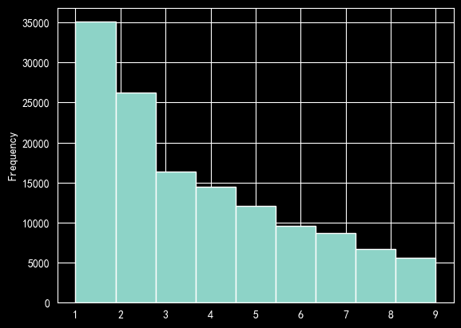

```python
#查看RF分布
rf['recency'].plot.hist(bins=9)
```

```python
recency = rf['recency'].value_counts()
recency
```

```
recency
1    35088
2    26255
3    16366
4    14479
5    12077
6     9627
7     8699
8     6746
9     5645
Name: count, dtype: int64
```

此处分配分值仍采用了业务方法，根据分布情况，将：

- recency = 1 → score: 5
- recency = 2、3 → score: 4
- recency = 4、5 → score: 3
- recency = 6、7 → score: 2
- recency = 8、9 → score: 1

```python
#为R分配分值
r_score = {1:5, 2:4, 3:4, 4:3, 5:3, 6:2, 7:2, 8:1, 9:1}
rf['r_score'] = rf['recency'].map(r_score)
rf
```

|  | user_id | recency | frequency | r_score |
| --- | --- | --- | --- | --- |
| 0 | 27 | 3 | 2 | 4 |
| 1 | 43 | 1 | 6 | 5 |
| 2 | 63 | 6 | 3 | 2 |
| 3 | 77 | 2 | 2 | 4 |
| 4 | 90 | 7 | 1 | 2 |
| ... | ... | ... | ... | ... |
| 134977 | 1017960 | 1 | 3 | 5 |
| 134978 | 1017965 | 7 | 1 | 2 |
| 134979 | 1017972 | 5 | 4 | 3 |
| 134980 | 1017997 | 3 | 2 | 4 |
| 134981 | 1018011 | 8 | 1 | 1 |

134982 rows × 4 columns

接下来对frequency分配分值，首先查看frequency的取值和分布：

```python
frequency = rf['frequency'].value_counts().reset_index()
frequency.sort_values('frequency', ascending=True, inplace=True)
frequency
```

|  | frequency | count |
| --- | --- | --- |
| 0 | 1 | 46058 |
| 1 | 2 | 31467 |
| 2 | 3 | 20327 |
| 3 | 4 | 12599 |
| 4 | 5 | 8099 |
| ... | ... | ... |
| 48 | 72 | 1 |
| 51 | 84 | 1 |
| 54 | 87 | 1 |
| 53 | 93 | 1 |
| 58 | 159 | 1 |

63 rows × 2 columns

```python
f1 = (frequency[frequency['frequency']==1]['count']/frequency['count'].sum()).values[0]
print(f'只购买1次的用户占比:{round(f1*100, 2)}%')
print(f"最高购买频率:{frequency['frequency'].max()}次")
```

```
只购买1次的用户占比:34.12%
最高购买频率:159次
```

此处使用分段打分+业务打分的方法，先对低频段做细分，保证低频用户得到更精细的区分，对高频段先做 log1p 压缩，再线性归一到剩余的较高分值区间，避免高频极端值把分布拉得很散。

```python
import numpy as np
```

```python
# 计算f score
def freq_to_score_piecewise(freq_series, low_cut=5, n_score=5):
    freq = np.sort(freq_series.unique())

    low_freq = freq[freq<=low_cut]
    high_freq = freq[freq>low_cut]

    mapping = {}
    low_score_max = max(1, n_score//2)

    low_bins = np.linspace(1, low_score_max+1, num=len(low_freq), endpoint=True)
    for v, s in zip(low_freq, np.ceil(low_bins).astype(int)):
        mapping[int(v)] = int(min(max(1,s),n_score))

    high_log = np.log1p(high_freq)
    hl_min, hl_max = high_log.min(), high_log.max()
    high_norm = (high_log - hl_min)/(hl_max - hl_min)
    target_low = low_score_max + 1
    target_high = n_score
    for v, hn in zip(high_freq, high_norm):
        sc = int(np.ceil(target_low+hn*(target_high-target_low)))
        mapping[int(v)] = sc

    return mapping

mapping = freq_to_score_piecewise(rf['frequency'], low_cut=5, n_score=5)
```

- low_cut：低频阈值
- low_score_max：给低段分配多少低分
- n_score：最大分值

得到mapping时，再对结果进行微调，此处得到的mapping中分值为5的数据分配得过少，一直到频次为42时，才将频次分配为5，事实上，高频次购买的用户非常少，因此设置购买频次只要在16次以上，就为高频次购买用户，分配分值为5。

```python
for k, v in mapping.items():
    if k>=16:
        mapping[k] = 5
mapping
```

```
{1: 1,
 2: 2,
 3: 2,
 4: 3,
 5: 3,
 6: 3,
 7: 4,
 8: 4,
 9: 4,
 10: 4,
 11: 4,
 12: 4,
 13: 4,
 14: 4,
 15: 4,
```

[output cut: 48 more lines]

统计每个f-score的频率：

```python
rf['f_score'] = rf['frequency'].map(mapping).fillna(1).astype(int)
freq_table = rf['f_score'].value_counts().sort_index().to_frame('user_count')
freq_table['pct'] = freq_table['user_count']/freq_table['user_count'].sum()
freq_table
```

| f_score | user_count | pct |
| --- | --- | --- |
| 1 | 46058 | 0.341216 |
| 2 | 51794 | 0.383710 |
| 3 | 25814 | 0.191240 |
| 4 | 10420 | 0.077195 |
| 5 | 896 | 0.006638 |

将用户分类：

```python
rf['r_avg'] = rf['r_score'].mean().round(2)
rf['f_avg'] = rf['f_score'].mean().round(2)

conditions = [
    (rf['r_score'] > rf['r_avg']) & (rf['f_score'] > rf['f_avg']),
    (rf['r_score'] > rf['r_avg']) & (rf['f_score'] <= rf['f_avg']),
    (rf['r_score'] <= rf['r_avg']) & (rf['f_score'] > rf['f_avg']),
    (rf['r_score'] <= rf['r_avg']) & (rf['f_score'] <= rf['f_avg'])
]

choices = ['价值用户', '发展用户', '保持用户', '挽留用户']

rf['user_cate'] = np.select(conditions, choices)
rf
```

|  | user_id | recency | frequency | r_score | f_score | r_avg | f_avg | user_cate |
| --- | --- | --- | --- | --- | --- | --- | --- | --- |
| 0 | 27 | 3 | 2 | 4 | 2 | 3.52 | 2.02 | 发展用户 |
| 1 | 43 | 1 | 6 | 5 | 3 | 3.52 | 2.02 | 价值用户 |
| 2 | 63 | 6 | 3 | 2 | 2 | 3.52 | 2.02 | 挽留用户 |
| 3 | 77 | 2 | 2 | 4 | 2 | 3.52 | 2.02 | 发展用户 |
| 4 | 90 | 7 | 1 | 2 | 1 | 3.52 | 2.02 | 挽留用户 |
| ... | ... | ... | ... | ... | ... | ... | ... | ... |
| 134977 | 1017960 | 1 | 3 | 5 | 2 | 3.52 | 2.02 | 发展用户 |
| 134978 | 1017965 | 7 | 1 | 2 | 1 | 3.52 | 2.02 | 挽留用户 |
| 134979 | 1017972 | 5 | 4 | 3 | 3 | 3.52 | 2.02 | 保持用户 |
| 134980 | 1017997 | 3 | 2 | 4 | 2 | 3.52 | 2.02 | 发展用户 |
| 134981 | 1018011 | 8 | 1 | 1 | 1 | 3.52 | 2.02 | 挽留用户 |

134982 rows × 8 columns

计算每个用户分类的数量，和其贡献的购买量

```python
users_buy = taobao[taobao['behavior_type']=='buy'].groupby('user_id')['behavior_type'].count().reset_index(name='purchase')

category_user_buy = pd.merge(rf, users_buy, how='inner', on='user_id')

segments = category_user_buy.groupby('user_cate').agg(count=('user_id', 'nunique'), purchase=('purchase', 'sum')).reset_index()
segments
```

|  | user_cate | count | purchase |
| --- | --- | --- | --- |
| 0 | 价值用户 | 28788 | 188035 |
| 1 | 保持用户 | 8342 | 46617 |
| 2 | 发展用户 | 48921 | 92866 |
| 3 | 挽留用户 | 48931 | 77107 |

```python
segments['rate'] = round(segments['count']/segments['count'].sum(), 2)
segments
```

|  | user_cate | count | purchase | rate |
| --- | --- | --- | --- | --- |
| 0 | 价值用户 | 28788 | 188035 | 0.21 |
| 1 | 保持用户 | 8342 | 46617 | 0.06 |
| 2 | 发展用户 | 48921 | 92866 | 0.36 |
| 3 | 挽留用户 | 48931 | 77107 | 0.36 |

```python
print(segments.to_markdown(index=False))
```

```
| user_cate   |   count |   purchase |   rate |
|:------------|--------:|-----------:|-------:|
| 价值用户    |   28788 |     188035 |   0.21 |
| 保持用户    |    8342 |      46617 |   0.06 |
| 发展用户    |   48921 |      92866 |   0.36 |
| 挽留用户    |   48931 |      77107 |   0.36 |
```

## **六、品类分析**

计算复购率，复购率有两种不同的计算维度，一种是用户维度，一种是订单的维度。

本项目从用户维度计算复购率：

复购率=复购用户数/购买用户数

用户在一天内只要无论购买多少次，都算作一次。因此复购用户数是指活动范围内在不同日有过购买行为的用户数。

```python
# 计算统计时间内的复购率，一天的算一单
# 筛选出所有购买记录， 根据日期和user_id进行分组
all_rebuy = taobao[taobao['behavior_type']=='buy'].groupby(['user_id', 'date'])['item_id'].nunique().reset_index(name='one_day')
all_rebuy
```

|  | user_id | date | one_day |
| --- | --- | --- | --- |
| 0 | 27 | 2017-11-25 | 1 |
| 1 | 27 | 2017-12-01 | 1 |
| 2 | 43 | 2017-11-29 | 1 |
| 3 | 43 | 2017-12-01 | 1 |
| 4 | 43 | 2017-12-02 | 3 |
| ... | ... | ... | ... |
| 268047 | 1017972 | 2017-11-25 | 2 |
| 268048 | 1017972 | 2017-11-29 | 2 |
| 268049 | 1017997 | 2017-11-25 | 1 |
| 268050 | 1017997 | 2017-12-01 | 1 |
| 268051 | 1018011 | 2017-11-26 | 1 |

268052 rows × 3 columns

```python
rebuy_user = all_rebuy.groupby('user_id')['date'].nunique().reset_index(name='count')
rebuy_user
```

|  | user_id | count |
| --- | --- | --- |
| 0 | 27 | 2 |
| 1 | 43 | 4 |
| 2 | 63 | 2 |
| 3 | 77 | 1 |
| 4 | 90 | 1 |
| ... | ... | ... |
| 134977 | 1017960 | 3 |
| 134978 | 1017965 | 1 |
| 134979 | 1017972 | 2 |
| 134980 | 1017997 | 2 |
| 134981 | 1018011 | 1 |

134982 rows × 2 columns

```python
rebuy_user['if_rebuy'] = np.where(rebuy_user['count']>1, 1, 0)
rebuy_user
```

|  | user_id | count | if_rebuy |
| --- | --- | --- | --- |
| 0 | 27 | 2 | 1 |
| 1 | 43 | 4 | 1 |
| 2 | 63 | 2 | 1 |
| 3 | 77 | 1 | 0 |
| 4 | 90 | 1 | 0 |
| ... | ... | ... | ... |
| 134977 | 1017960 | 3 | 1 |
| 134978 | 1017965 | 1 | 0 |
| 134979 | 1017972 | 2 | 1 |
| 134980 | 1017997 | 2 | 1 |
| 134981 | 1018011 | 1 | 0 |

134982 rows × 3 columns

```python
rebuy_rate_days = rebuy_user['if_rebuy'].mean()
print(f'复购率:{100*rebuy_rate_days:.2f}%')
```

```
复购率:55.08%
```

进一步对品类的点击量、浏览人数、收藏量、加购量、购买量进行统计：

对每件商品计算其购买率，即在该品类所有浏览行为中，有多少次转化成了购买，以及每件商品的人均浏览量（pv/uv）。

```python
items = taobao.groupby('item_category').agg(
    pv = ('behavior_type', lambda x:(x=='pv').sum()),
    cart = ('behavior_type', lambda x:(x=='cart').sum()),
    fav = ('behavior_type', lambda x:(x=='fav').sum()),
    buy = ('behavior_type', lambda x:(x=='buy').sum())
)

items_uv = taobao[taobao['behavior_type']=='pv'].groupby('item_category').agg(uv=('user_id', 'nunique')).reset_index()

items = pd.merge(items, items_uv, how='left', on='item_category')
items['pv/uv'] = round(items['pv']/items['uv'], 2)
items['convert_buy_rate'] = round(items['buy']/items['pv'], 2)

items.sort_values('convert_buy_rate', ascending=False, inplace=True)
items
```

|  | item_category | pv | cart | fav | buy | uv | pv/uv | convert_buy_rate |
| --- | --- | --- | --- | --- | --- | --- | --- | --- |
| 1197 | 748535 | 0 | 0 | 0 | 1 | NaN | NaN | inf |
| 6732 | 4026780 | 0 | 0 | 0 | 1 | NaN | NaN | inf |
| 7327 | 4387171 | 0 | 0 | 0 | 1 | NaN | NaN | inf |
| 7261 | 4349434 | 0 | 0 | 0 | 1 | NaN | NaN | inf |
| 7700 | 4630498 | 0 | 0 | 0 | 1 | NaN | NaN | inf |
| ... | ... | ... | ... | ... | ... | ... | ... | ... |
| 7436 | 4461258 | 0 | 1 | 0 | 0 | NaN | NaN | NaN |
| 7968 | 4803781 | 0 | 0 | 1 | 0 | NaN | NaN | NaN |
| 7983 | 4816919 | 0 | 0 | 1 | 0 | NaN | NaN | NaN |
| 8329 | 5009745 | 0 | 1 | 0 | 0 | NaN | NaN | NaN |
| 8506 | 5126559 | 0 | 1 | 0 | 0 | NaN | NaN | NaN |

8562 rows × 8 columns

# **数据分析报告**

#### **数据概况**

- 数据来源：淘宝用户行为数据集（含点击、收藏、加购、购买行为）。
- 时间跨度：2017-11-25 至 2017-12-03（共 9 天）。
- 样本规模：约2000万条行为记录，包含用户 ID、商品 ID、行为类型、时间等字段。
- 数据内总用户数为198001，涉及商品数为2208950个，涉及商品种类为8562种。

### **二、 流量与活跃度诊断**

访问量与成交量变化折线图：

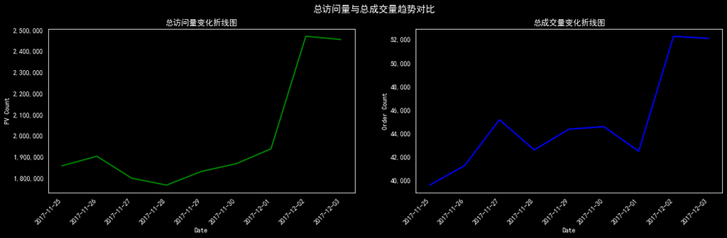

从访问量与成交量变化图中可以看出，访问量与成交量在11-25至12-01之间存在小幅波动，从12-02开始访问量和成交量均出现大幅上升，2日3日两天连续保持高访问量和高成交量。此现象原因之一为12月2日和3日为周末，同时考虑2日3日可能存在某些促销活动，可结合实际业务情况进行具体分析。（图中周五访问量有上升，但成交量出现下降，推测此现象可能与周末活动导致周五推迟成交有关。）

时间维度洞察： 根据活跃热力图显示，无论是工作日还是周末，用户的活跃低谷均在凌晨2:00-5:00，从18:00开始流量急速攀升，在21:00-22:00达到顶峰。

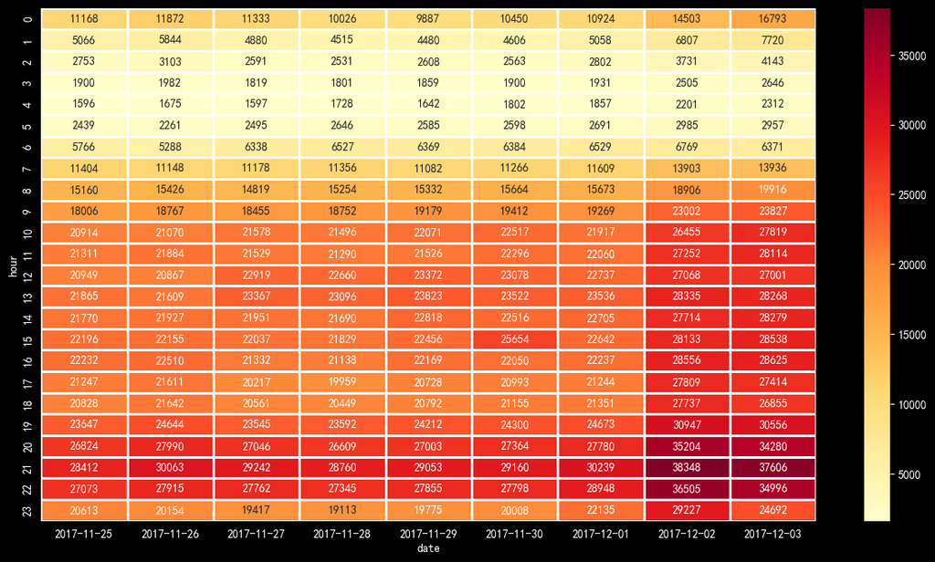

此外，周末的整体DAU较工作日提升了约34.24%。

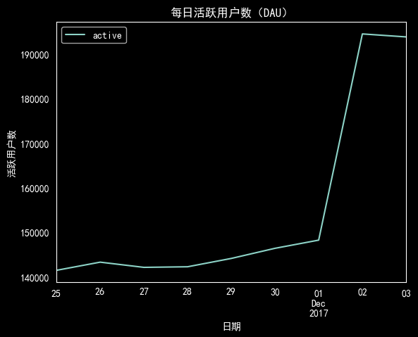

### **三、 核心转化漏斗分析**

| 漏斗路径 | 分母 | 分子 | 转化率 |
| --- | --- | --- | --- |
| 浏览➡收藏/加购物车 | 浏览过商品的用户数 | 浏览后收藏/加购物车的用户数 | 74.85% |
| 浏览➡收藏/加购物车➡购买 | 浏览后收藏/加购物车的用户数 | 浏览后收藏/加购物车并且购买的用户数 | 32.78% |
| 浏览➡购买 | 浏览过商品的用户数 | 浏览过商品并且最终购买的用户数 | 56.58% |
| 收藏/加购物车➡购买 | 收藏/加购物车的用户数 | 收藏/加购物车后购买的用户数 | 33.85% |
| 浏览➡购买（直购） | 浏览过商品的用户数 | 浏览后直接购买的用户数 | 46.86% |
| 无浏览直接收藏/加购物车➡购买 | 无浏览直接收藏/加购物车的用户数 | 无浏览直接收藏/加购物车后购买的用户数 | 11.11% |

**业务落地建议：**

- 针对“只看不收藏不买”的用户：说明商品详情页（详情图、买家秀）缺乏吸引力。建议优化前端 UI，或者在详情页增加“限时满减”、“倒计时促销”组件，制造紧迫感，逼迫用户先加入购物车。
- 针对“收藏/加购物车但未支付”的用户：这部分是待唤醒的“肥羊”。建议在购物车页面增加“降价提醒”，或通过系统自动发放“购物车清空专属立减券”促成临门一脚。

## **四、用户价值分层**

[output not shown]

RFM 价值分层：

- 价值用户：占比虽少，仅占21%，但贡献极大。
- 保持用户：占比最低，但贡献率很高。
- 发展用户：占比高，需要加快转化。
- 挽留用户：曾经的死忠粉正在流失。

业务落地建议：

- 对待价值用户：发放会员专享权益，提供极速退款、免邮、送高端小样等增值服务，可通过积分体系提高复购率。
- 对待保持用户：避免流失，可通过低门槛优惠券维持。
- 对待发展用户：通过新客优惠等活动加快转化，激发用户活跃度。
- 对待挽留用户：立刻安排专属客服外呼跟进，或定向下发高额“老客回归券”进行紧急召回。

### **五、商品动销与爆款盘点**

热门商品Top10

| ('pv_top10', 'item_id') | ('pv_top10', 'count') | ('sale_top10', 'item_id') | ('sale_top10', 'count') | ('heat_top10', 'item_id') | ('heat_top10', 'score_heat') |
| --- | --- | --- | --- | --- | --- |
| 812879 | 6014 | 3122135 | 292 | 812879 | 8241 |
| 3845720 | 5098 | 3031354 | 161 | 3031354 | 7127 |
| 138964 | 4194 | 2560262 | 137 | 3845720 | 6581 |
| 2331370 | 3916 | 2964774 | 135 | 2331370 | 6265 |
| 2032668 | 3798 | 1910706 | 133 | 138964 | 5892 |
| 59883 | 3553 | 3964583 | 133 | 1535294 | 5809 |
| 1535294 | 3537 | 1415828 | 119 | 2818406 | 5088 |
| 3031354 | 3475 | 1116492 | 115 | 2560262 | 5067 |
| 3371523 | 3460 | 1034594 | 107 | 4443059 | 5039 |
| 4211339 | 3392 | 740947 | 106 | 2453685 | 4790 |

热门品类Top10

| ('cat_pv_top10', 'item_category') | ('cat_pv_top10', 'count') | ('cat_sale_top10', 'item_category') | ('cat_sale_top10', 'count') | ('cat_heat_top10', 'item_category') | ('cat_heat_top10', 'score_heat') |
| --- | --- | --- | --- | --- | --- |
| 4756105 | 901040 | 1464116 | 7030 | 4756105 | 1256896 |
| 4145813 | 634522 | 2735466 | 6774 | 4145813 | 939674 |
| 2355072 | 623979 | 4145813 | 6475 | 2355072 | 820424 |
| 3607361 | 587034 | 2885642 | 6329 | 982926 | 813789 |
| 982926 | 558090 | 4756105 | 5536 | 3607361 | 762573 |
| 2520377 | 401186 | 4801426 | 5281 | 4801426 | 586987 |
| 4801426 | 371631 | 982926 | 4989 | 2520377 | 547022 |
| 1320293 | 355507 | 2640118 | 3727 | 1320293 | 514543 |
| 2465336 | 303424 | 4159072 | 3561 | 2465336 | 449955 |
| 3002561 | 283270 | 1320293 | 3405 | 3002561 | 429718 |

业务落地建议： 对于“高流量、高转化”的绝对爆款：给予首页 Banner 强曝光，作为引流款持续拉新。 对于“高流量、低转化”的商品：排查是否引流词与实际商品不符（标题党），或者价格定得过高，建议配合打折促销测试弹性。